# Prepping NEUS Data

```r
library(dggridR)
library(data.table)
library(rgdal)
library(raster)
library(sp)
library(rnaturalearth)
library(rnaturalearthdata)
library(rgeos)
library(taxize) #standardizing names
library(geosphere)  #to calculate distance between lat lon of grid cells
library(googledrive)
```

Moving forward, I plan to use data directly from FishGlob.

November 30, 2021

```r
drive_download("NEUS_clean.csv",
               overwrite = T)
```

```
File downloaded:
• NEUS_clean.csv <id: 1TeKdTLeCVjtp7OpmZpgtxVWaBafywpak>
Saved locally as:
• NEUS_clean.csv
```

```r
neus <- fread("NEUS_clean.csv")

file.remove("NEUS_clean.csv")
```

```
[1] TRUE
```

```r
summary(as.factor(neus$season))
```

```
  Fall Spring
223264 199386
```

```r
neus_fall <- neus[season == "Fall"]
neus_spring <- neus[season == "Spring"]
```

##FALL

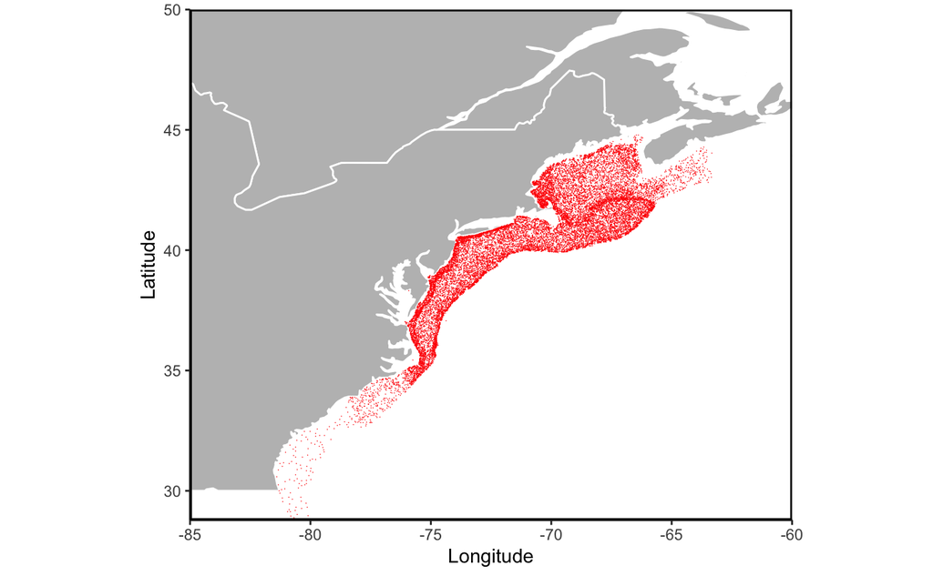

```r
# Get Unique lines in the data table
unique_neus_latlon_fall <- unique(neus_fall[,.(latitude, longitude)])
unique_neus_latlon.sf <- unique_neus_latlon_fall

#make lat lon coordinates into polygon
coordinates(unique_neus_latlon.sf) <- ~latitude + longitude
unique_neus_latlon.sf@proj4string <- crs("+proj=longlat +datum=WGS84 +no_defs +ellps=WGS84 +towgs84=0,0,0")

saveRDS(unique_neus_latlon_fall, "unique_neus_latlon_fall.rds")

#plot north america
world <- ne_countries(scale = "medium", returnclass = "sp")

world_ext <- extent(-85, -60,30, 50)

north_america_spdf <- crop(world, world_ext)

north_america_df <- fortify(north_america_spdf)
(na_outline <- ggplot(north_america_df, aes(long, lat, group = group)) +
  geom_polygon(color = "white", fill = "grey") +
  labs(x = "Longitude", y = "Latitude") +
  coord_equal() +
  theme_classic() +
  scale_x_continuous(expand = c(0,0)) +
  scale_y_continuous(expand = c(0,0)) +
  theme(panel.border = element_rect(color = "black", fill = NA, size = 1)) +
 geom_point(unique_neus_latlon_fall, mapping = aes(longitude, latitude), inherit.aes = FALSE, shape = 18, size = 0.001, color = "red") +
  coord_equal())
```

Playing around with dggridR (package that makes grid cells)

```r
dggs <- dgconstruct(spacing = 111, metric = T, resround = 'nearest')
```

```
Resolution: 8, Area (km^2): 7774.20548276313, Spacing (km): 87.0821287828498, CLS (km): 99.4910857271796
```

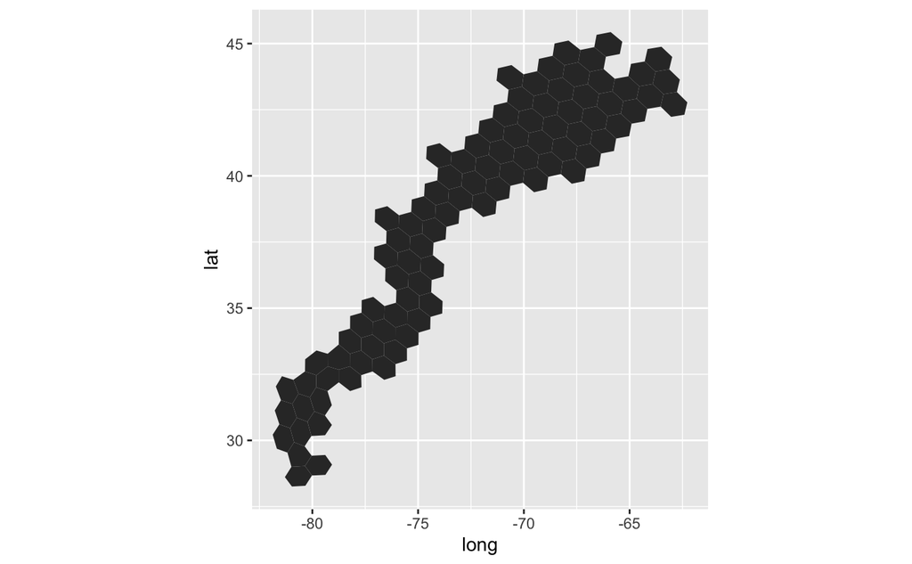

```r
unique_neus_latlon_fall[,cell := dgGEO_to_SEQNUM(dggs, longitude, latitude)] #get corresponding grid cells for NEUS trawl

#centersof cells
neus_cellcenters <- dgSEQNUM_to_GEO(dggs, unique_neus_latlon_fall[,cell])

#linking cell centers to unique_neus_latlon
unique_neus_latlon_fall[,LON_CENTER := neus_cellcenters$lon_deg][,LAT_CENTER := neus_cellcenters$lat_deg]

#link centers back to main data table

neus_fall <- merge(neus_fall, unique_neus_latlon_fall, by = c("latitude", "longitude"))

#number of tows in each cell
towcount <- unique_neus_latlon_fall[, .N, by = cell]

#get the grid cell boundary for cells which had trawls
grid_neus_fall <- dgcellstogrid(dggs, unique_neus_latlon_fall[,cell], frame = T, wrapcells = F)

#update grid properties to include # of trawls in each cell
grid_neus_fall <- merge(grid_neus_fall, unique_neus_latlon_fall, by = "cell")

ggplot(data = grid_neus_fall, aes(x = long, y = lat, group = cell)) +
  geom_polygon() +
  coord_quickmap()
```

```r
saveRDS(grid_neus_fall, "grid_neus_fall.rds")
```

Trying to plot with grid overlaying

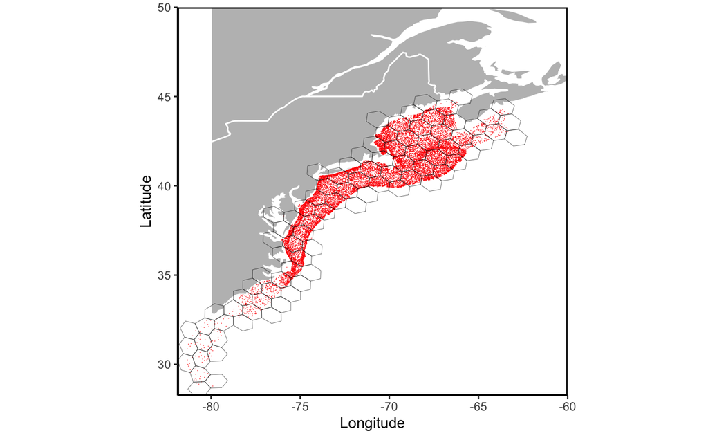

```r
na_outline +
   geom_polygon(grid_neus_fall, mapping = aes(x = long,y = lat, group = cell), inherit.aes = FALSE, color = "black", fill = NA, size = 0.1)

ggsave(filename = "grid_NEUS_cells_spacing_111_fall.pdf")
```

```r
NA
```

Cleaning spp names (must be ID’d to species!)

```r
#unique species names
neus_fall.clean <- neus_fall[rank == "Species"]
```

Now, we’ll overlay grid cells onto this list of tows (dat_neus) using lat and lon and gridrr package

```r
year_grid <- data.table(table(neus_fall.clean$cell, neus_fall.clean$year))

#there are some grid cells with infrequent records, I will delete these
grid_cells_to_exclude <- unique(year_grid[N == 0]$V1)

#delete these grid cells from full data table
neus_fall.reduced <- neus_fall.clean[!cell %in% grid_cells_to_exclude]

#115782 observations left, this should be great

#how many tows (TOW) per cell in a given year

haul_cell_unique <- unique(neus_fall.reduced[,.(haul_id, cell, year)])

neus_fall_samplingevents_byyear <- haul_cell_unique[,.N, .(year, cell)]

neus_fall_cells_lessthan3 <- neus_fall_samplingevents_byyear[N<3,]

cells_to_delete <- unique(neus_fall_cells_lessthan3[,cell])

neus_fall.reduced.again <- neus_fall.reduced[!cell %in% cells_to_delete]

#down to 85563 observations

saveRDS(neus_fall.reduced.again, "neus_fall.reduced.again.rds")
```

Find distance between center of each grid cell

```r
#just need grid cell # and center lat lon for each grid cell
neus_fall_grid_cells <- unique(neus_fall.reduced.again[,.(cell, LON_CENTER, LAT_CENTER)])

neus_fall_grid_cells <- setorder(neus_fall_grid_cells, cell)

neus_fall_reg_distances <- distm(neus_fall_grid_cells[,.(LON_CENTER, LAT_CENTER)])

colnames(neus_fall_reg_distances) <- neus_fall_grid_cells$cell
rownames(neus_fall_reg_distances) <- neus_fall_grid_cells$cell

#reorient to long form
neus_fall_reg_distances.l <- melt(as.matrix(neus_fall_reg_distances), varnames = c("cell1", "cell2"), value.name = "distance(m)") #matrix to data frame
neus_fall_reg_distances.l <- data.table(neus_fall_reg_distances.l) #and then to data table
neus_fall_reg_distances.l <- neus_fall_reg_distances.l[cell1 > cell2,] # get rid of repetitions and self-comparisons
saveRDS(neus_fall_reg_distances.l, "neus_fall_reg_distances.l.rds")
```

CHECK CLAIM THAT #no years have way more tows than others, because this isn’t true